# Risk Factor Analysis

## Outcome Variable

**Outcome Variable:** sstunted

## Predictor Variables

**Intervention Variable:** vagbrth

**Adjustment Set:**

unadjusted

## Stratifying Variables

The analysis was stratified on these variable(s):

- agecat
- studyid
- country

## Data Summary

| agecat | studyid | country | A | n | nA | nAY0 | nAY1 |
| --- | --- | --- | --- | --- | --- | --- | --- |
| Birth | ki1000108-CMC-V-BCS-2002 | INDIA | 0 | 90 | 11 | 10 | 1 |
| Birth | ki1000108-CMC-V-BCS-2002 | INDIA | 1 | 90 | 79 | 77 | 2 |
| Birth | ki1000108-IRC | INDIA | 0 | 388 | 68 | 67 | 1 |
| Birth | ki1000108-IRC | INDIA | 1 | 388 | 320 | 305 | 15 |
| Birth | ki1017093c-NIH-Crypto | BANGLADESH | 0 | 19 | 1 | 1 | 0 |
| Birth | ki1017093c-NIH-Crypto | BANGLADESH | 1 | 19 | 18 | 18 | 0 |
| Birth | ki1119695-PROBIT | BELARUS | 0 | 6779 | 716 | 715 | 1 |
| Birth | ki1119695-PROBIT | BELARUS | 1 | 6779 | 6063 | 6059 | 4 |
| Birth | ki1126311-ZVITAMBO | ZIMBABWE | 0 | 13716 | 1162 | 1133 | 29 |
| Birth | ki1126311-ZVITAMBO | ZIMBABWE | 1 | 13716 | 12554 | 12150 | 404 |
| Birth | kiGH5241-JiVitA-3 | BANGLADESH | 0 | 9731 | 1 | 0 | 1 |
| Birth | kiGH5241-JiVitA-3 | BANGLADESH | 1 | 9731 | 9730 | 8636 | 1094 |
| Birth | kiGH5241-JiVitA-4 | BANGLADESH | 0 | 224 | 0 | 0 | 0 |
| Birth | kiGH5241-JiVitA-4 | BANGLADESH | 1 | 224 | 224 | 206 | 18 |
| 3 months | ki1000108-CMC-V-BCS-2002 | INDIA | 0 | 362 | 25 | 23 | 2 |
| 3 months | ki1000108-CMC-V-BCS-2002 | INDIA | 1 | 362 | 337 | 306 | 31 |
| 3 months | ki1000108-IRC | INDIA | 0 | 407 | 69 | 62 | 7 |
| 3 months | ki1000108-IRC | INDIA | 1 | 407 | 338 | 309 | 29 |
| 3 months | ki1017093b-PROVIDE | BANGLADESH | 0 | 645 | 150 | 148 | 2 |
| 3 months | ki1017093b-PROVIDE | BANGLADESH | 1 | 645 | 495 | 487 | 8 |
| 3 months | ki1017093c-NIH-Crypto | BANGLADESH | 0 | 471 | 193 | 186 | 7 |
| 3 months | ki1017093c-NIH-Crypto | BANGLADESH | 1 | 471 | 278 | 267 | 11 |
| 3 months | ki1066203-TanzaniaChild2 | TANZANIA, UNITED REPUBLIC OF | 0 | 2265 | 201 | 200 | 1 |
| 3 months | ki1066203-TanzaniaChild2 | TANZANIA, UNITED REPUBLIC OF | 1 | 2265 | 2064 | 2040 | 24 |
| 3 months | ki1119695-PROBIT | BELARUS | 0 | 8057 | 845 | 834 | 11 |
| 3 months | ki1119695-PROBIT | BELARUS | 1 | 8057 | 7212 | 7157 | 55 |
| 3 months | ki1126311-ZVITAMBO | ZIMBABWE | 0 | 9123 | 797 | 761 | 36 |
| 3 months | ki1126311-ZVITAMBO | ZIMBABWE | 1 | 9123 | 8326 | 7842 | 484 |
| 3 months | kiGH5241-JiVitA-3 | BANGLADESH | 0 | 12270 | 700 | 663 | 37 |
| 3 months | kiGH5241-JiVitA-3 | BANGLADESH | 1 | 12270 | 11570 | 10584 | 986 |

[output cut: 88 more lines]

The following strata were considered:

- agecat: 12 months, studyid: ki1000108-CMC-V-BCS-2002, country: INDIA
- agecat: 12 months, studyid: ki1000108-IRC, country: INDIA
- agecat: 12 months, studyid: ki1017093b-PROVIDE, country: BANGLADESH
- agecat: 12 months, studyid: ki1017093c-NIH-Crypto, country: BANGLADESH
- agecat: 12 months, studyid: ki1066203-TanzaniaChild2, country: TANZANIA, UNITED REPUBLIC OF
- agecat: 12 months, studyid: ki1119695-PROBIT, country: BELARUS
- agecat: 12 months, studyid: ki1126311-ZVITAMBO, country: ZIMBABWE
- agecat: 12 months, studyid: kiGH5241-JiVitA-3, country: BANGLADESH
- agecat: 12 months, studyid: kiGH5241-JiVitA-4, country: BANGLADESH
- agecat: 18 months, studyid: ki1000108-CMC-V-BCS-2002, country: INDIA
- agecat: 18 months, studyid: ki1000108-IRC, country: INDIA
- agecat: 18 months, studyid: ki1017093b-PROVIDE, country: BANGLADESH
- agecat: 18 months, studyid: ki1017093c-NIH-Crypto, country: BANGLADESH
- agecat: 18 months, studyid: ki1066203-TanzaniaChild2, country: TANZANIA, UNITED REPUBLIC OF
- agecat: 18 months, studyid: ki1119695-PROBIT, country: BELARUS
- agecat: 18 months, studyid: ki1126311-ZVITAMBO, country: ZIMBABWE
- agecat: 18 months, studyid: kiGH5241-JiVitA-4, country: BANGLADESH
- agecat: 24 months, studyid: ki1000108-CMC-V-BCS-2002, country: INDIA
- agecat: 24 months, studyid: ki1000108-IRC, country: INDIA
- agecat: 24 months, studyid: ki1017093b-PROVIDE, country: BANGLADESH
- agecat: 24 months, studyid: ki1017093c-NIH-Crypto, country: BANGLADESH
- agecat: 24 months, studyid: ki1066203-TanzaniaChild2, country: TANZANIA, UNITED REPUBLIC OF
- agecat: 24 months, studyid: ki1119695-PROBIT, country: BELARUS
- agecat: 24 months, studyid: ki1126311-ZVITAMBO, country: ZIMBABWE
- agecat: 24 months, studyid: kiGH5241-JiVitA-3, country: BANGLADESH
- agecat: 24 months, studyid: kiGH5241-JiVitA-4, country: BANGLADESH
- agecat: 3 months, studyid: ki1000108-CMC-V-BCS-2002, country: INDIA
- agecat: 3 months, studyid: ki1000108-IRC, country: INDIA
- agecat: 3 months, studyid: ki1017093b-PROVIDE, country: BANGLADESH
- agecat: 3 months, studyid: ki1017093c-NIH-Crypto, country: BANGLADESH
- agecat: 3 months, studyid: ki1066203-TanzaniaChild2, country: TANZANIA, UNITED REPUBLIC OF
- agecat: 3 months, studyid: ki1119695-PROBIT, country: BELARUS
- agecat: 3 months, studyid: ki1126311-ZVITAMBO, country: ZIMBABWE
- agecat: 3 months, studyid: kiGH5241-JiVitA-3, country: BANGLADESH
- agecat: 3 months, studyid: kiGH5241-JiVitA-4, country: BANGLADESH
- agecat: 6 months, studyid: ki1000108-CMC-V-BCS-2002, country: INDIA
- agecat: 6 months, studyid: ki1000108-IRC, country: INDIA
- agecat: 6 months, studyid: ki1017093b-PROVIDE, country: BANGLADESH
- agecat: 6 months, studyid: ki1017093c-NIH-Crypto, country: BANGLADESH
- agecat: 6 months, studyid: ki1066203-TanzaniaChild2, country: TANZANIA, UNITED REPUBLIC OF
- agecat: 6 months, studyid: ki1119695-PROBIT, country: BELARUS
- agecat: 6 months, studyid: ki1126311-ZVITAMBO, country: ZIMBABWE
- agecat: 6 months, studyid: kiGH5241-JiVitA-3, country: BANGLADESH
- agecat: 6 months, studyid: kiGH5241-JiVitA-4, country: BANGLADESH
- agecat: 9 months, studyid: ki1000108-CMC-V-BCS-2002, country: INDIA
- agecat: 9 months, studyid: ki1000108-IRC, country: INDIA
- agecat: 9 months, studyid: ki1017093b-PROVIDE, country: BANGLADESH
- agecat: 9 months, studyid: ki1017093c-NIH-Crypto, country: BANGLADESH
- agecat: 9 months, studyid: ki1066203-TanzaniaChild2, country: TANZANIA, UNITED REPUBLIC OF
- agecat: 9 months, studyid: ki1119695-PROBIT, country: BELARUS
- agecat: 9 months, studyid: ki1126311-ZVITAMBO, country: ZIMBABWE
- agecat: 9 months, studyid: kiGH5241-JiVitA-4, country: BANGLADESH
- agecat: Birth, studyid: ki1000108-CMC-V-BCS-2002, country: INDIA
- agecat: Birth, studyid: ki1000108-IRC, country: INDIA
- agecat: Birth, studyid: ki1017093c-NIH-Crypto, country: BANGLADESH
- agecat: Birth, studyid: ki1119695-PROBIT, country: BELARUS
- agecat: Birth, studyid: ki1126311-ZVITAMBO, country: ZIMBABWE
- agecat: Birth, studyid: kiGH5241-JiVitA-3, country: BANGLADESH
- agecat: Birth, studyid: kiGH5241-JiVitA-4, country: BANGLADESH

### Dropped Strata

Some strata were dropped due to rare outcomes:

- agecat: Birth, studyid: ki1000108-CMC-V-BCS-2002, country: INDIA
- agecat: Birth, studyid: ki1000108-IRC, country: INDIA
- agecat: Birth, studyid: ki1017093c-NIH-Crypto, country: BANGLADESH
- agecat: Birth, studyid: ki1119695-PROBIT, country: BELARUS
- agecat: Birth, studyid: kiGH5241-JiVitA-3, country: BANGLADESH
- agecat: Birth, studyid: kiGH5241-JiVitA-4, country: BANGLADESH
- agecat: 3 months, studyid: ki1000108-CMC-V-BCS-2002, country: INDIA
- agecat: 3 months, studyid: ki1017093b-PROVIDE, country: BANGLADESH
- agecat: 3 months, studyid: ki1066203-TanzaniaChild2, country: TANZANIA, UNITED REPUBLIC OF
- agecat: 3 months, studyid: kiGH5241-JiVitA-4, country: BANGLADESH
- agecat: 6 months, studyid: ki1000108-CMC-V-BCS-2002, country: INDIA
- agecat: 6 months, studyid: ki1017093b-PROVIDE, country: BANGLADESH
- agecat: 6 months, studyid: ki1017093c-NIH-Crypto, country: BANGLADESH
- agecat: 6 months, studyid: ki1066203-TanzaniaChild2, country: TANZANIA, UNITED REPUBLIC OF
- agecat: 6 months, studyid: kiGH5241-JiVitA-4, country: BANGLADESH
- agecat: 9 months, studyid: ki1000108-CMC-V-BCS-2002, country: INDIA
- agecat: 9 months, studyid: ki1017093b-PROVIDE, country: BANGLADESH
- agecat: 9 months, studyid: ki1066203-TanzaniaChild2, country: TANZANIA, UNITED REPUBLIC OF
- agecat: 9 months, studyid: kiGH5241-JiVitA-4, country: BANGLADESH
- agecat: 12 months, studyid: ki1017093b-PROVIDE, country: BANGLADESH
- agecat: 12 months, studyid: ki1066203-TanzaniaChild2, country: TANZANIA, UNITED REPUBLIC OF
- agecat: 18 months, studyid: ki1000108-IRC, country: INDIA
- agecat: 18 months, studyid: ki1119695-PROBIT, country: BELARUS
- agecat: 24 months, studyid: ki1000108-IRC, country: INDIA
- agecat: 24 months, studyid: ki1066203-TanzaniaChild2, country: TANZANIA, UNITED REPUBLIC OF
- agecat: 24 months, studyid: ki1119695-PROBIT, country: BELARUS

## Methods Detail

We’re interested in the causal parameters $E[Y_a]$ for all values of $a \in \mathcal{A}$. These parameters represent the mean outcome if, possibly contrary to fact, we intervened to set all units to have $A=a$. Under the randomization and positivity assumptions, these are identified by the statistical parameters $\psi_a=E_W[E_{Y|A,W}(Y|A=a,W)]$. In addition, we’re interested in the mean of $Y$, $E[Y]$ under no intervention (the observed mean). We will estimate these parameters by using SuperLearner to fit the relevant likelihood factors – $E_{Y|A,W}(Y|A=a,W)$ and $p(A=a|W)$, and then updating our likelihood fit using a joint TMLE.

For unadjusted analyses ($W=\{\}$), initial likelihoods were estimated using Lrnr_glm to estimate the simple $E(Y|A)$ and Lrnr_mean to estimate $p(A)$. For adjusted analyses, a small library containing Lrnr_glmnet, Lrnr_xgboost, and Lrnr_mean was used.

Having estimated these parameters, we will then use the delta method to estimate relative risks and attributable risks relative to a prespecified baseline level of $A$.

# Results Detail

## Results Plots

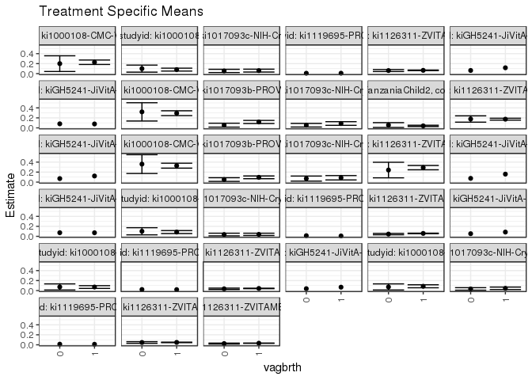

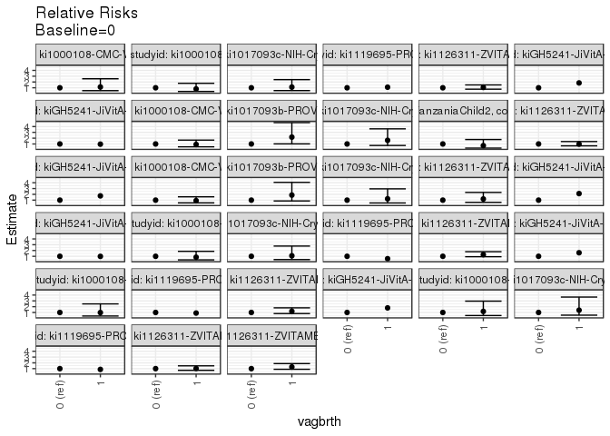

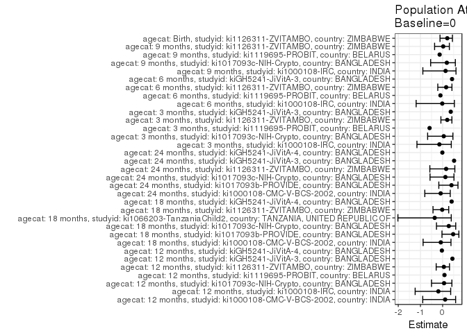

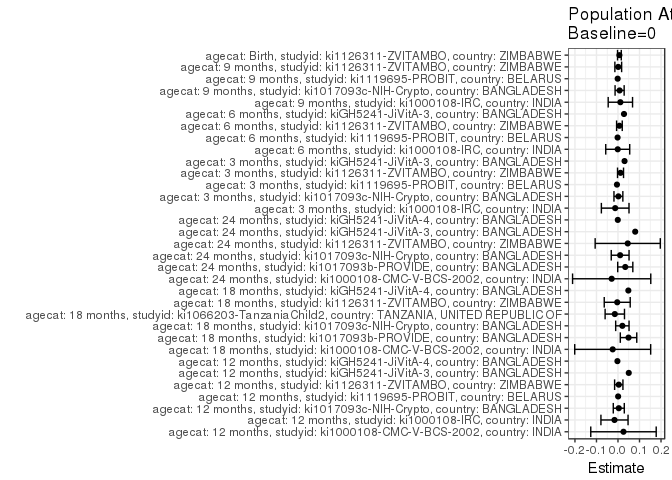

## Results Table

### Parameter: TSM

| agecat | studyid | country | intervention_level | baseline_level | estimate | ci_lower | ci_upper |
| --- | --- | --- | --- | --- | --- | --- | --- |
| Birth | ki1126311-ZVITAMBO | ZIMBABWE | 0 | NA | 0.0249570 | 0.0159875 | 0.0339265 |
| Birth | ki1126311-ZVITAMBO | ZIMBABWE | 1 | NA | 0.0321810 | 0.0290937 | 0.0352682 |
| 3 months | ki1000108-IRC | INDIA | 0 | NA | 0.1014493 | 0.0301223 | 0.1727762 |
| 3 months | ki1000108-IRC | INDIA | 1 | NA | 0.0857988 | 0.0559047 | 0.1156929 |
| 3 months | ki1017093c-NIH-Crypto | BANGLADESH | 0 | NA | 0.0362694 | 0.0098649 | 0.0626740 |
| 3 months | ki1017093c-NIH-Crypto | BANGLADESH | 1 | NA | 0.0395683 | 0.0166283 | 0.0625084 |
| 3 months | ki1119695-PROBIT | BELARUS | 0 | NA | 0.0130178 | NA | NA |
| 3 months | ki1119695-PROBIT | BELARUS | 1 | NA | 0.0076262 | NA | NA |
| 3 months | ki1126311-ZVITAMBO | ZIMBABWE | 0 | NA | 0.0451694 | 0.0307506 | 0.0595881 |
| 3 months | ki1126311-ZVITAMBO | ZIMBABWE | 1 | NA | 0.0581312 | 0.0531048 | 0.0631575 |
| 3 months | kiGH5241-JiVitA-3 | BANGLADESH | 0 | NA | 0.0528571 | NA | NA |
| 3 months | kiGH5241-JiVitA-3 | BANGLADESH | 1 | NA | 0.0852204 | NA | NA |
| 6 months | ki1000108-IRC | INDIA | 0 | NA | 0.0724638 | 0.0112169 | 0.1337106 |
| 6 months | ki1000108-IRC | INDIA | 1 | NA | 0.0710059 | 0.0435916 | 0.0984202 |
| 6 months | ki1119695-PROBIT | BELARUS | 0 | NA | 0.0209360 | NA | NA |
| 6 months | ki1119695-PROBIT | BELARUS | 1 | NA | 0.0188239 | NA | NA |
| 6 months | ki1126311-ZVITAMBO | ZIMBABWE | 0 | NA | 0.0353607 | 0.0217460 | 0.0489754 |
| 6 months | ki1126311-ZVITAMBO | ZIMBABWE | 1 | NA | 0.0426805 | 0.0381119 | 0.0472491 |
| 6 months | kiGH5241-JiVitA-3 | BANGLADESH | 0 | NA | 0.0379507 | NA | NA |
| 6 months | kiGH5241-JiVitA-3 | BANGLADESH | 1 | NA | 0.0678097 | NA | NA |
| 9 months | ki1000108-IRC | INDIA | 0 | NA | 0.0724638 | 0.0112169 | 0.1337106 |
| 9 months | ki1000108-IRC | INDIA | 1 | NA | 0.0857988 | 0.0559047 | 0.1156929 |
| 9 months | ki1017093c-NIH-Crypto | BANGLADESH | 0 | NA | 0.0324324 | 0.0068774 | 0.0579874 |
| 9 months | ki1017093c-NIH-Crypto | BANGLADESH | 1 | NA | 0.0452830 | 0.0202212 | 0.0703449 |
| 9 months | ki1119695-PROBIT | BELARUS | 0 | NA | 0.0127389 | NA | NA |
| 9 months | ki1119695-PROBIT | BELARUS | 1 | NA | 0.0110481 | NA | NA |
| 9 months | ki1126311-ZVITAMBO | ZIMBABWE | 0 | NA | 0.0468750 | 0.0304981 | 0.0632519 |
| 9 months | ki1126311-ZVITAMBO | ZIMBABWE | 1 | NA | 0.0482135 | 0.0431838 | 0.0532433 |
| 12 months | ki1000108-CMC-V-BCS-2002 | INDIA | 0 | NA | 0.2000000 | 0.0429894 | 0.3570106 |
| 12 months | ki1000108-CMC-V-BCS-2002 | INDIA | 1 | NA | 0.2274052 | 0.1829863 | 0.2718242 |
| 12 months | ki1000108-IRC | INDIA | 0 | NA | 0.1000000 | 0.0296351 | 0.1703649 |
| 12 months | ki1000108-IRC | INDIA | 1 | NA | 0.0803571 | 0.0512543 | 0.1094600 |
| 12 months | ki1017093c-NIH-Crypto | BANGLADESH | 0 | NA | 0.0540541 | 0.0214334 | 0.0866747 |
| 12 months | ki1017093c-NIH-Crypto | BANGLADESH | 1 | NA | 0.0603774 | 0.0316681 | 0.0890866 |
| 12 months | ki1119695-PROBIT | BELARUS | 0 | NA | 0.0073439 | NA | NA |
| 12 months | ki1119695-PROBIT | BELARUS | 1 | NA | 0.0080937 | NA | NA |
| 12 months | ki1126311-ZVITAMBO | ZIMBABWE | 0 | NA | 0.0618182 | 0.0416902 | 0.0819462 |
| 12 months | ki1126311-ZVITAMBO | ZIMBABWE | 1 | NA | 0.0657873 | 0.0595864 | 0.0719882 |
| 12 months | kiGH5241-JiVitA-3 | BANGLADESH | 0 | NA | 0.0636364 | NA | NA |
| 12 months | kiGH5241-JiVitA-3 | BANGLADESH | 1 | NA | 0.1169834 | NA | NA |
| 12 months | kiGH5241-JiVitA-4 | BANGLADESH | 0 | NA | 0.0810811 | NA | NA |
| 12 months | kiGH5241-JiVitA-4 | BANGLADESH | 1 | NA | 0.0782347 | NA | NA |
| 18 months | ki1000108-CMC-V-BCS-2002 | INDIA | 0 | NA | 0.3200000 | 0.1368964 | 0.5031036 |
| 18 months | ki1000108-CMC-V-BCS-2002 | INDIA | 1 | NA | 0.2936047 | 0.2454139 | 0.3417954 |
| 18 months | ki1017093b-PROVIDE | BANGLADESH | 0 | NA | 0.0542636 | 0.0151357 | 0.0933914 |
| 18 months | ki1017093b-PROVIDE | BANGLADESH | 1 | NA | 0.1182033 | 0.0874090 | 0.1489976 |
| 18 months | ki1017093c-NIH-Crypto | BANGLADESH | 0 | NA | 0.0533333 | 0.0173275 | 0.0893391 |
| 18 months | ki1017093c-NIH-Crypto | BANGLADESH | 1 | NA | 0.0869565 | 0.0504935 | 0.1234196 |
| 18 months | ki1066203-TanzaniaChild2 | TANZANIA, UNITED REPUBLIC OF | 0 | NA | 0.0561798 | 0.0083154 | 0.1040442 |
| 18 months | ki1066203-TanzaniaChild2 | TANZANIA, UNITED REPUBLIC OF | 1 | NA | 0.0398633 | 0.0269160 | 0.0528106 |
| 18 months | ki1126311-ZVITAMBO | ZIMBABWE | 0 | NA | 0.1773050 | 0.1142460 | 0.2403639 |
| 18 months | ki1126311-ZVITAMBO | ZIMBABWE | 1 | NA | 0.1734365 | 0.1545879 | 0.1922851 |
| 18 months | kiGH5241-JiVitA-4 | BANGLADESH | 0 | NA | 0.0704225 | NA | NA |
| 18 months | kiGH5241-JiVitA-4 | BANGLADESH | 1 | NA | 0.1220513 | NA | NA |
| 24 months | ki1000108-CMC-V-BCS-2002 | INDIA | 0 | NA | 0.3600000 | 0.1715900 | 0.5484100 |
| 24 months | ki1000108-CMC-V-BCS-2002 | INDIA | 1 | NA | 0.3285303 | 0.2790458 | 0.3780147 |
| 24 months | ki1017093b-PROVIDE | BANGLADESH | 0 | NA | 0.0510949 | 0.0141916 | 0.0879981 |
| 24 months | ki1017093b-PROVIDE | BANGLADESH | 1 | NA | 0.0954545 | 0.0679748 | 0.1229342 |
| 24 months | ki1017093c-NIH-Crypto | BANGLADESH | 0 | NA | 0.0707071 | 0.0201159 | 0.1212983 |
| 24 months | ki1017093c-NIH-Crypto | BANGLADESH | 1 | NA | 0.0869565 | 0.0433483 | 0.1305648 |
| 24 months | ki1126311-ZVITAMBO | ZIMBABWE | 0 | NA | 0.2413793 | 0.0854619 | 0.3972967 |
| 24 months | ki1126311-ZVITAMBO | ZIMBABWE | 1 | NA | 0.2897862 | 0.2464028 | 0.3331696 |
| 24 months | kiGH5241-JiVitA-3 | BANGLADESH | 0 | NA | 0.0748899 | NA | NA |
| 24 months | kiGH5241-JiVitA-3 | BANGLADESH | 1 | NA | 0.1593665 | NA | NA |
| 24 months | kiGH5241-JiVitA-4 | BANGLADESH | 0 | NA | 0.0724638 | NA | NA |
| 24 months | kiGH5241-JiVitA-4 | BANGLADESH | 1 | NA | 0.0715005 | NA | NA |

### Parameter: E(Y)

| agecat | studyid | country | intervention_level | baseline_level | estimate | ci_lower | ci_upper |
| --- | --- | --- | --- | --- | --- | --- | --- |
| Birth | ki1126311-ZVITAMBO | ZIMBABWE | NA | NA | 0.0315690 | 0.0286427 | 0.0344952 |
| 3 months | ki1000108-IRC | INDIA | NA | NA | 0.0884521 | 0.0608318 | 0.1160724 |
| 3 months | ki1017093c-NIH-Crypto | BANGLADESH | NA | NA | 0.0382166 | 0.0208840 | 0.0555492 |
| 3 months | ki1119695-PROBIT | BELARUS | NA | NA | 0.0081916 | NA | NA |
| 3 months | ki1126311-ZVITAMBO | ZIMBABWE | NA | NA | 0.0569988 | 0.0522411 | 0.0617564 |
| 3 months | kiGH5241-JiVitA-3 | BANGLADESH | NA | NA | 0.0833741 | NA | NA |
| 6 months | ki1000108-IRC | INDIA | NA | NA | 0.0712531 | 0.0462303 | 0.0962759 |
| 6 months | ki1119695-PROBIT | BELARUS | NA | NA | 0.0190476 | NA | NA |
| 6 months | ki1126311-ZVITAMBO | ZIMBABWE | NA | NA | 0.0420515 | 0.0377145 | 0.0463885 |
| 6 months | kiGH5241-JiVitA-3 | BANGLADESH | NA | NA | 0.0659102 | NA | NA |
| 9 months | ki1000108-IRC | INDIA | NA | NA | 0.0835381 | 0.0566237 | 0.1104525 |
| 9 months | ki1017093c-NIH-Crypto | BANGLADESH | NA | NA | 0.0400000 | 0.0218745 | 0.0581255 |
| 9 months | ki1119695-PROBIT | BELARUS | NA | NA | 0.0112254 | NA | NA |
| 9 months | ki1126311-ZVITAMBO | ZIMBABWE | NA | NA | 0.0481009 | 0.0432927 | 0.0529092 |
| 12 months | ki1000108-CMC-V-BCS-2002 | INDIA | NA | NA | 0.2255435 | 0.1827844 | 0.2683026 |
| 12 months | ki1000108-IRC | INDIA | NA | NA | 0.0837438 | 0.0567661 | 0.1107216 |
| 12 months | ki1017093c-NIH-Crypto | BANGLADESH | NA | NA | 0.0577778 | 0.0361963 | 0.0793593 |
| 12 months | ki1119695-PROBIT | BELARUS | NA | NA | 0.0080145 | NA | NA |
| 12 months | ki1126311-ZVITAMBO | ZIMBABWE | NA | NA | 0.0654611 | 0.0595342 | 0.0713879 |
| 12 months | kiGH5241-JiVitA-3 | BANGLADESH | NA | NA | 0.1137124 | NA | NA |
| 12 months | kiGH5241-JiVitA-4 | BANGLADESH | NA | NA | 0.0784314 | NA | NA |
| 18 months | ki1000108-CMC-V-BCS-2002 | INDIA | NA | NA | 0.2953930 | 0.2487810 | 0.3420050 |
| 18 months | ki1017093b-PROVIDE | BANGLADESH | NA | NA | 0.1032609 | 0.0778527 | 0.1286690 |
| 18 months | ki1017093c-NIH-Crypto | BANGLADESH | NA | NA | 0.0736842 | 0.0473818 | 0.0999866 |
| 18 months | ki1066203-TanzaniaChild2 | TANZANIA, UNITED REPUBLIC OF | NA | NA | 0.0413650 | 0.0288076 | 0.0539225 |
| 18 months | ki1126311-ZVITAMBO | ZIMBABWE | NA | NA | 0.1737589 | 0.1556995 | 0.1918183 |
| 18 months | kiGH5241-JiVitA-4 | BANGLADESH | NA | NA | 0.1185468 | NA | NA |
| 24 months | ki1000108-CMC-V-BCS-2002 | INDIA | NA | NA | 0.3306452 | 0.2827744 | 0.3785159 |
| 24 months | ki1017093b-PROVIDE | BANGLADESH | NA | NA | 0.0849220 | 0.0621566 | 0.1076874 |
| 24 months | ki1017093c-NIH-Crypto | BANGLADESH | NA | NA | 0.0807692 | 0.0475849 | 0.1139536 |
| 24 months | ki1126311-ZVITAMBO | ZIMBABWE | NA | NA | 0.2866667 | 0.2448394 | 0.3284940 |
| 24 months | kiGH5241-JiVitA-3 | BANGLADESH | NA | NA | 0.1548735 | NA | NA |
| 24 months | kiGH5241-JiVitA-4 | BANGLADESH | NA | NA | 0.0715631 | NA | NA |

### Parameter: RR

| agecat | studyid | country | intervention_level | baseline_level | estimate | ci_lower | ci_upper |
| --- | --- | --- | --- | --- | --- | --- | --- |
| Birth | ki1126311-ZVITAMBO | ZIMBABWE | 0 | 0 | 1.0000000 | 1.0000000 | 1.000000 |
| Birth | ki1126311-ZVITAMBO | ZIMBABWE | 1 | 0 | 1.2894585 | 0.8889094 | 1.870498 |
| 3 months | ki1000108-IRC | INDIA | 0 | 0 | 1.0000000 | 1.0000000 | 1.000000 |
| 3 months | ki1000108-IRC | INDIA | 1 | 0 | 0.8457312 | 0.3858792 | 1.853588 |
| 3 months | ki1017093c-NIH-Crypto | BANGLADESH | 0 | 0 | 1.0000000 | 1.0000000 | 1.000000 |
| 3 months | ki1017093c-NIH-Crypto | BANGLADESH | 1 | 0 | 1.0909558 | 0.4301585 | 2.766851 |
| 3 months | ki1119695-PROBIT | BELARUS | 0 | 0 | 1.0000000 | NA | NA |
| 3 months | ki1119695-PROBIT | BELARUS | 1 | 0 | 0.5858292 | NA | NA |
| 3 months | ki1126311-ZVITAMBO | ZIMBABWE | 0 | 0 | 1.0000000 | 1.0000000 | 1.000000 |
| 3 months | ki1126311-ZVITAMBO | ZIMBABWE | 1 | 0 | 1.2869592 | 0.9245609 | 1.791406 |
| 3 months | kiGH5241-JiVitA-3 | BANGLADESH | 0 | 0 | 1.0000000 | NA | NA |
| 3 months | kiGH5241-JiVitA-3 | BANGLADESH | 1 | 0 | 1.6122778 | NA | NA |
| 6 months | ki1000108-IRC | INDIA | 0 | 0 | 1.0000000 | 1.0000000 | 1.000000 |
| 6 months | ki1000108-IRC | INDIA | 1 | 0 | 0.9798817 | 0.3869206 | 2.481564 |
| 6 months | ki1119695-PROBIT | BELARUS | 0 | 0 | 1.0000000 | NA | NA |
| 6 months | ki1119695-PROBIT | BELARUS | 1 | 0 | 0.8991168 | NA | NA |
| 6 months | ki1126311-ZVITAMBO | ZIMBABWE | 0 | 0 | 1.0000000 | 1.0000000 | 1.000000 |
| 6 months | ki1126311-ZVITAMBO | ZIMBABWE | 1 | 0 | 1.2070044 | 0.8093821 | 1.799965 |
| 6 months | kiGH5241-JiVitA-3 | BANGLADESH | 0 | 0 | 1.0000000 | NA | NA |
| 6 months | kiGH5241-JiVitA-3 | BANGLADESH | 1 | 0 | 1.7867856 | NA | NA |
| 9 months | ki1000108-IRC | INDIA | 0 | 0 | 1.0000000 | 1.0000000 | 1.000000 |
| 9 months | ki1000108-IRC | INDIA | 1 | 0 | 1.1840237 | 0.4745983 | 2.953892 |
| 9 months | ki1017093c-NIH-Crypto | BANGLADESH | 0 | 0 | 1.0000000 | 1.0000000 | 1.000000 |
| 9 months | ki1017093c-NIH-Crypto | BANGLADESH | 1 | 0 | 1.3962264 | 0.5330604 | 3.657087 |
| 9 months | ki1119695-PROBIT | BELARUS | 0 | 0 | 1.0000000 | NA | NA |
| 9 months | ki1119695-PROBIT | BELARUS | 1 | 0 | 0.8672738 | NA | NA |
| 9 months | ki1126311-ZVITAMBO | ZIMBABWE | 0 | 0 | 1.0000000 | 1.0000000 | 1.000000 |
| 9 months | ki1126311-ZVITAMBO | ZIMBABWE | 1 | 0 | 1.0285550 | 0.7142930 | 1.481081 |
| 12 months | ki1000108-CMC-V-BCS-2002 | INDIA | 0 | 0 | 1.0000000 | 1.0000000 | 1.000000 |
| 12 months | ki1000108-CMC-V-BCS-2002 | INDIA | 1 | 0 | 1.1370262 | 0.5063274 | 2.553345 |
| 12 months | ki1000108-IRC | INDIA | 0 | 0 | 1.0000000 | 1.0000000 | 1.000000 |
| 12 months | ki1000108-IRC | INDIA | 1 | 0 | 0.8035714 | 0.3641925 | 1.773038 |
| 12 months | ki1017093c-NIH-Crypto | BANGLADESH | 0 | 0 | 1.0000000 | 1.0000000 | 1.000000 |
| 12 months | ki1017093c-NIH-Crypto | BANGLADESH | 1 | 0 | 1.1169811 | 0.5180557 | 2.408326 |
| 12 months | ki1119695-PROBIT | BELARUS | 0 | 0 | 1.0000000 | NA | NA |
| 12 months | ki1119695-PROBIT | BELARUS | 1 | 0 | 1.1020860 | NA | NA |
| 12 months | ki1126311-ZVITAMBO | ZIMBABWE | 0 | 0 | 1.0000000 | 1.0000000 | 1.000000 |
| 12 months | ki1126311-ZVITAMBO | ZIMBABWE | 1 | 0 | 1.0642068 | 0.7582524 | 1.493614 |
| 12 months | kiGH5241-JiVitA-3 | BANGLADESH | 0 | 0 | 1.0000000 | NA | NA |
| 12 months | kiGH5241-JiVitA-3 | BANGLADESH | 1 | 0 | 1.8383101 | NA | NA |
| 12 months | kiGH5241-JiVitA-4 | BANGLADESH | 0 | 0 | 1.0000000 | NA | NA |
| 12 months | kiGH5241-JiVitA-4 | BANGLADESH | 1 | 0 | 0.9648947 | NA | NA |
| 18 months | ki1000108-CMC-V-BCS-2002 | INDIA | 0 | 0 | 1.0000000 | 1.0000000 | 1.000000 |
| 18 months | ki1000108-CMC-V-BCS-2002 | INDIA | 1 | 0 | 0.9175145 | 0.5059279 | 1.663939 |
| 18 months | ki1017093b-PROVIDE | BANGLADESH | 0 | 0 | 1.0000000 | 1.0000000 | 1.000000 |
| 18 months | ki1017093b-PROVIDE | BANGLADESH | 1 | 0 | 2.1783181 | 1.0119336 | 4.689112 |
| 18 months | ki1017093c-NIH-Crypto | BANGLADESH | 0 | 0 | 1.0000000 | 1.0000000 | 1.000000 |
| 18 months | ki1017093c-NIH-Crypto | BANGLADESH | 1 | 0 | 1.6304348 | 0.7364680 | 3.609549 |
| 18 months | ki1066203-TanzaniaChild2 | TANZANIA, UNITED REPUBLIC OF | 0 | 0 | 1.0000000 | 1.0000000 | 1.000000 |
| 18 months | ki1066203-TanzaniaChild2 | TANZANIA, UNITED REPUBLIC OF | 1 | 0 | 0.7095672 | 0.2851058 | 1.765961 |
| 18 months | ki1126311-ZVITAMBO | ZIMBABWE | 0 | 0 | 1.0000000 | 1.0000000 | 1.000000 |
| 18 months | ki1126311-ZVITAMBO | ZIMBABWE | 1 | 0 | 0.9781818 | 0.6743904 | 1.418821 |
| 18 months | kiGH5241-JiVitA-4 | BANGLADESH | 0 | 0 | 1.0000000 | NA | NA |
| 18 months | kiGH5241-JiVitA-4 | BANGLADESH | 1 | 0 | 1.7331282 | NA | NA |
| 24 months | ki1000108-CMC-V-BCS-2002 | INDIA | 0 | 0 | 1.0000000 | 1.0000000 | 1.000000 |
| 24 months | ki1000108-CMC-V-BCS-2002 | INDIA | 1 | 0 | 0.9125841 | 0.5293636 | 1.573228 |
| 24 months | ki1017093b-PROVIDE | BANGLADESH | 0 | 0 | 1.0000000 | 1.0000000 | 1.000000 |
| 24 months | ki1017093b-PROVIDE | BANGLADESH | 1 | 0 | 1.8681818 | 0.8585216 | 4.065248 |
| 24 months | ki1017093c-NIH-Crypto | BANGLADESH | 0 | 0 | 1.0000000 | 1.0000000 | 1.000000 |
| 24 months | ki1017093c-NIH-Crypto | BANGLADESH | 1 | 0 | 1.2298137 | 0.5133025 | 2.946492 |
| 24 months | ki1126311-ZVITAMBO | ZIMBABWE | 0 | 0 | 1.0000000 | 1.0000000 | 1.000000 |
| 24 months | ki1126311-ZVITAMBO | ZIMBABWE | 1 | 0 | 1.2005429 | 0.6186031 | 2.329932 |
| 24 months | kiGH5241-JiVitA-3 | BANGLADESH | 0 | 0 | 1.0000000 | NA | NA |
| 24 months | kiGH5241-JiVitA-3 | BANGLADESH | 1 | 0 | 2.1280114 | NA | NA |
| 24 months | kiGH5241-JiVitA-4 | BANGLADESH | 0 | 0 | 1.0000000 | NA | NA |
| 24 months | kiGH5241-JiVitA-4 | BANGLADESH | 1 | 0 | 0.9867069 | NA | NA |

### Parameter: PAR

| agecat | studyid | country | intervention_level | baseline_level | estimate | ci_lower | ci_upper |
| --- | --- | --- | --- | --- | --- | --- | --- |
| Birth | ki1126311-ZVITAMBO | ZIMBABWE | 0 | NA | 0.0066120 | -0.0020704 | 0.0152944 |
| 3 months | ki1000108-IRC | INDIA | 0 | NA | -0.0129972 | -0.0772265 | 0.0512321 |
| 3 months | ki1017093c-NIH-Crypto | BANGLADESH | 0 | NA | 0.0019471 | -0.0186985 | 0.0225927 |
| 3 months | ki1119695-PROBIT | BELARUS | 0 | NA | -0.0048261 | NA | NA |
| 3 months | ki1126311-ZVITAMBO | ZIMBABWE | 0 | NA | 0.0118294 | -0.0021065 | 0.0257654 |
| 3 months | kiGH5241-JiVitA-3 | BANGLADESH | 0 | NA | 0.0305169 | NA | NA |
| 6 months | ki1000108-IRC | INDIA | 0 | NA | -0.0012107 | -0.0569370 | 0.0545156 |
| 6 months | ki1119695-PROBIT | BELARUS | 0 | NA | -0.0018883 | NA | NA |
| 6 months | ki1126311-ZVITAMBO | ZIMBABWE | 0 | NA | 0.0066909 | -0.0064360 | 0.0198177 |
| 6 months | kiGH5241-JiVitA-3 | BANGLADESH | 0 | NA | 0.0279595 | NA | NA |
| 9 months | ki1000108-IRC | INDIA | 0 | NA | 0.0110743 | -0.0455266 | 0.0676752 |
| 9 months | ki1017093c-NIH-Crypto | BANGLADESH | 0 | NA | 0.0075676 | -0.0135188 | 0.0286539 |
| 9 months | ki1119695-PROBIT | BELARUS | 0 | NA | -0.0015134 | NA | NA |
| 9 months | ki1126311-ZVITAMBO | ZIMBABWE | 0 | NA | 0.0012259 | -0.0144650 | 0.0169168 |
| 12 months | ki1000108-CMC-V-BCS-2002 | INDIA | 0 | NA | 0.0255435 | -0.1265459 | 0.1776328 |
| 12 months | ki1000108-IRC | INDIA | 0 | NA | -0.0162562 | -0.0792776 | 0.0467652 |
| 12 months | ki1017093c-NIH-Crypto | BANGLADESH | 0 | NA | 0.0037237 | -0.0218680 | 0.0293155 |
| 12 months | ki1119695-PROBIT | BELARUS | 0 | NA | 0.0006705 | NA | NA |
| 12 months | ki1126311-ZVITAMBO | ZIMBABWE | 0 | NA | 0.0036429 | -0.0156874 | 0.0229732 |
| 12 months | kiGH5241-JiVitA-3 | BANGLADESH | 0 | NA | 0.0500760 | NA | NA |
| 12 months | kiGH5241-JiVitA-4 | BANGLADESH | 0 | NA | -0.0026497 | NA | NA |
| 18 months | ki1000108-CMC-V-BCS-2002 | INDIA | 0 | NA | -0.0246070 | -0.2011195 | 0.1519054 |
| 18 months | ki1017093b-PROVIDE | BANGLADESH | 0 | NA | 0.0489973 | 0.0107744 | 0.0872202 |
| 18 months | ki1017093c-NIH-Crypto | BANGLADESH | 0 | NA | 0.0203509 | -0.0107095 | 0.0514112 |
| 18 months | ki1066203-TanzaniaChild2 | TANZANIA, UNITED REPUBLIC OF | 0 | NA | -0.0148147 | -0.0598367 | 0.0302072 |
| 18 months | ki1126311-ZVITAMBO | ZIMBABWE | 0 | NA | -0.0035461 | -0.0638771 | 0.0567849 |
| 18 months | kiGH5241-JiVitA-4 | BANGLADESH | 0 | NA | 0.0481243 | NA | NA |
| 24 months | ki1000108-CMC-V-BCS-2002 | INDIA | 0 | NA | -0.0293548 | -0.2110652 | 0.1523555 |
| 24 months | ki1017093b-PROVIDE | BANGLADESH | 0 | NA | 0.0338271 | -0.0012929 | 0.0689471 |
| 24 months | ki1017093c-NIH-Crypto | BANGLADESH | 0 | NA | 0.0100622 | -0.0313086 | 0.0514329 |
| 24 months | ki1126311-ZVITAMBO | ZIMBABWE | 0 | NA | 0.0452874 | -0.1061274 | 0.1967021 |
| 24 months | kiGH5241-JiVitA-3 | BANGLADESH | 0 | NA | 0.0799836 | NA | NA |
| 24 months | kiGH5241-JiVitA-4 | BANGLADESH | 0 | NA | -0.0009007 | NA | NA |

### Parameter: PAF

| agecat | studyid | country | intervention_level | baseline_level | estimate | ci_lower | ci_upper |
| --- | --- | --- | --- | --- | --- | --- | --- |
| Birth | ki1126311-ZVITAMBO | ZIMBABWE | 0 | NA | 0.2094462 | -0.1185678 | 0.4412718 |
| 3 months | ki1000108-IRC | INDIA | 0 | NA | -0.1469404 | -1.1581079 | 0.3904511 |
| 3 months | ki1017093c-NIH-Crypto | BANGLADESH | 0 | NA | 0.0509499 | -0.6760726 | 0.4626151 |
| 3 months | ki1119695-PROBIT | BELARUS | 0 | NA | -0.5891519 | NA | NA |
| 3 months | ki1126311-ZVITAMBO | ZIMBABWE | 0 | NA | 0.2075379 | -0.0781159 | 0.4175058 |
| 3 months | kiGH5241-JiVitA-3 | BANGLADESH | 0 | NA | 0.3660243 | NA | NA |
| 6 months | ki1000108-IRC | INDIA | 0 | NA | -0.0169915 | -1.1942765 | 0.5286502 |
| 6 months | ki1119695-PROBIT | BELARUS | 0 | NA | -0.0991379 | NA | NA |
| 6 months | ki1126311-ZVITAMBO | ZIMBABWE | 0 | NA | 0.1591108 | -0.2183008 | 0.4196059 |
| 6 months | kiGH5241-JiVitA-3 | BANGLADESH | 0 | NA | 0.4242062 | NA | NA |
| 9 months | ki1000108-IRC | INDIA | 0 | NA | 0.1325661 | -0.8918760 | 0.6022775 |
| 9 months | ki1017093c-NIH-Crypto | BANGLADESH | 0 | NA | 0.1891892 | -0.5409130 | 0.5733606 |
| 9 months | ki1119695-PROBIT | BELARUS | 0 | NA | -0.1348195 | NA | NA |
| 9 months | ki1126311-ZVITAMBO | ZIMBABWE | 0 | NA | 0.0254867 | -0.3619442 | 0.3027055 |
| 12 months | ki1000108-CMC-V-BCS-2002 | INDIA | 0 | NA | 0.1132530 | -0.8966036 | 0.5854061 |
| 12 months | ki1000108-IRC | INDIA | 0 | NA | -0.1941176 | -1.2387515 | 0.3630749 |
| 12 months | ki1017093c-NIH-Crypto | BANGLADESH | 0 | NA | 0.0644491 | -0.5011145 | 0.4169295 |
| 12 months | ki1119695-PROBIT | BELARUS | 0 | NA | 0.0836656 | NA | NA |
| 12 months | ki1126311-ZVITAMBO | ZIMBABWE | 0 | NA | 0.0556496 | -0.2909757 | 0.3092065 |
| 12 months | kiGH5241-JiVitA-3 | BANGLADESH | 0 | NA | 0.4403743 | NA | NA |
| 12 months | kiGH5241-JiVitA-4 | BANGLADESH | 0 | NA | -0.0337838 | NA | NA |
| 18 months | ki1000108-CMC-V-BCS-2002 | INDIA | 0 | NA | -0.0833028 | -0.8806241 | 0.3759812 |
| 18 months | ki1017093b-PROVIDE | BANGLADESH | 0 | NA | 0.4745002 | -0.0299245 | 0.7318735 |
| 18 months | ki1017093c-NIH-Crypto | BANGLADESH | 0 | NA | 0.2761905 | -0.2774753 | 0.5898940 |
| 18 months | ki1066203-TanzaniaChild2 | TANZANIA, UNITED REPUBLIC OF | 0 | NA | -0.3581461 | -2.0161267 | 0.3884339 |
| 18 months | ki1126311-ZVITAMBO | ZIMBABWE | 0 | NA | -0.0204082 | -0.4339978 | 0.2738951 |
| 18 months | kiGH5241-JiVitA-4 | BANGLADESH | 0 | NA | 0.4059518 | NA | NA |
| 24 months | ki1000108-CMC-V-BCS-2002 | INDIA | 0 | NA | -0.0887805 | -0.8036630 | 0.3427581 |
| 24 months | ki1017093b-PROVIDE | BANGLADESH | 0 | NA | 0.3983316 | -0.1719098 | 0.6910983 |
| 24 months | ki1017093c-NIH-Crypto | BANGLADESH | 0 | NA | 0.1245791 | -0.5676421 | 0.5111373 |
| 24 months | ki1126311-ZVITAMBO | ZIMBABWE | 0 | NA | 0.1579791 | -0.5764038 | 0.5502427 |
| 24 months | kiGH5241-JiVitA-3 | BANGLADESH | 0 | NA | 0.5164448 | NA | NA |
| 24 months | kiGH5241-JiVitA-4 | BANGLADESH | 0 | NA | -0.0125858 | NA | NA |